# AERMC/FLORECLIM - Adaptation locale de *Trifolium saxatile* : analyses préliminaires

Léa Bizard

05/11/2021

# 1. Protocole

Relevés botaniques avec abondance exprimée en % absolu (non dégradée en classes). Un relevé à la mise en place des placettes (2018) et un relevé l’année de l’enlèvement des placettes (2021).

# 2. Comparaisons inter-placettes

## 2.1 Distance inter-placettes - indice de Jaccard

### 2.1.1 Indice de Jaccard

```r
beta_18 <- vegdist(t_dat_prabs_18, binary = TRUE, method = "jaccard")
beta_18
```

```
##           BER_carr  BER_cari  BER_clap  BER_lac1  BER_lac2  VAL_eyme  MAU_arpo
## BER_cari 0.9130435
## BER_clap 0.8750000 0.9473684
## BER_lac1 0.9000000 0.8214286 0.9375000
## BER_lac2 0.9166667 0.8000000 0.6666667 0.9500000
## VAL_eyme 0.9655172 0.7575758 0.9583333 0.9142857 0.8846154
## MAU_arpo 0.9411765 0.8400000 0.9166667 0.9166667 0.7857143 0.7857143
## MAU_plah 0.9523810 0.8620690 0.9375000 0.9285714 0.8947368 0.9444444 0.7000000
## VAL_glab 0.9500000 0.8965517 0.9333333 0.9642857 0.8888889 0.8064516 0.9130435
## VAL_moba 0.8750000 0.7916667 0.9166667 0.8695652 0.8666667 0.7857143 0.8421053
## VIL_bas  0.9523810 0.9000000 0.9375000 0.9655172 0.8947368 0.8484848 0.8695652
## VIL_haut 0.9642857 0.8888889 0.9565217 0.9117647 0.9230769 0.8157895 0.8620690
## VAL_eyto 0.8750000 0.7391304 0.9166667 0.9166667 0.7857143 0.8666667 0.8421053
## MAU_plto 0.9615385 0.8823529 0.9523810 0.9705882 0.8695652 0.8974359 0.8076923
## VAL_moha 0.9583333 0.9411765 0.9473684 0.9354839 0.9565217 0.8285714 0.8400000
##           MAU_plah  VAL_glab  VAL_moba   VIL_bas  VIL_haut  VAL_eyto  MAU_plto
## BER_cari
## BER_clap
## BER_lac1
## BER_lac2
## VAL_eyme
## MAU_arpo
## MAU_plah
## VAL_glab 0.9259259
## VAL_moba 0.9166667 0.9130435
## VIL_bas  0.8888889 0.9259259 0.7619048
## VIL_haut 0.8787879 0.8750000 0.7777778 0.6785714
## VAL_eyto 0.8181818 0.8095238 0.8421053 0.9166667 0.9354839
## MAU_plto 0.7931034 0.8666667 0.9666667 0.8333333 0.8648649 0.8518519
## VAL_moha 0.9000000 0.6666667 0.8400000 0.7777778 0.8235294 0.9259259 0.8484848
```

```r
mb18 <- mean(beta_18)

beta_21 <- vegdist(na.omit(t_dat_prabs_21), binary = TRUE, method = "jaccard")
beta_21
```

```
##           BER_carr  BER_cari  BER_clap  BER_lac1  VAL_eyme  MAU_arpo  MAU_plah
## BER_cari 0.9285714
## BER_clap 0.8571429 1.0000000
## BER_lac1 0.7500000 0.8387097 0.8421053
## VAL_eyme 0.9512195 0.8333333 0.9705882 0.9347826
## MAU_arpo 0.9642857 0.8333333 0.9500000 0.9062500 0.7692308
## MAU_plah 0.9310345 0.8437500 0.9047619 0.9428571 0.8636364 0.8000000
## VAL_glab 0.9629630 0.9032258 0.9473684 0.9696970 0.8536585 0.8620690 0.7931034
## VAL_moba 0.9000000 0.8800000 1.0000000 0.8800000 0.8285714 0.8750000 1.0000000
## VIL_bas  0.8800000 0.7857143 0.9473684 0.9375000 0.8809524 0.9000000 0.7500000
## VIL_haut 0.9696970 0.8888889 0.9600000 0.9473684 0.8478261 0.8529412 0.8611111
## VAL_eyto 0.7391304 0.7500000 0.8947368 0.7037037 0.8571429 0.9032258 0.9090909
## MAU_plto 0.9459459 0.8750000 0.9666667 0.9534884 0.9056604 0.7428571 0.6060606
## VAL_moha 0.9333333 0.8823529 0.9565217 0.9142857 0.8409091 0.8787879 0.8529412
##           VAL_glab  VAL_moba   VIL_bas  VIL_haut  VAL_eyto  MAU_plto
## BER_cari
## BER_clap
## BER_lac1
## VAL_eyme
## MAU_arpo
## MAU_plah
## VAL_glab
## VAL_moba 0.9166667
## VIL_bas  0.8571429 0.9166667
## VIL_haut 0.8823529 0.8571429 0.7741935
## VAL_eyto 0.9354839 0.9200000 0.9000000 0.9459459
## MAU_plto 0.8378378 1.0000000 0.8378378 0.8863636 0.9268293
## VAL_moha 0.7142857 0.8888889 0.7142857 0.7272727 0.9428571 0.8809524
```

```r
mb21 <- mean(beta_21)
```

### 2.1.2 Regroupement hiérarchique sur les relevés de 2018

D’après l’analyse des “cor” pour chaque méthode, celle de McQuitty est la meilleure, on l’utilise donc pour la hierarchie finale.

```r
t_dat_prabs_clus_quit_18 <- hclust(beta_18, method = "mcquitty")
par(mar=c(6,4,2,2))
plot(t_dat_prabs_clus_quit_18, hang = -1, main="Jaccard Beta diversity ", ylab="Beta values",
     xlab="T_sax community sample", sub="WPGMA joining cluster")
```

```r
t_dat_prabs_coph_quit_18 <- cophenetic(t_dat_prabs_clus_quit_18)
cor(beta_18, t_dat_prabs_coph_quit_18)
```

```
## [1] 0.7621868
```

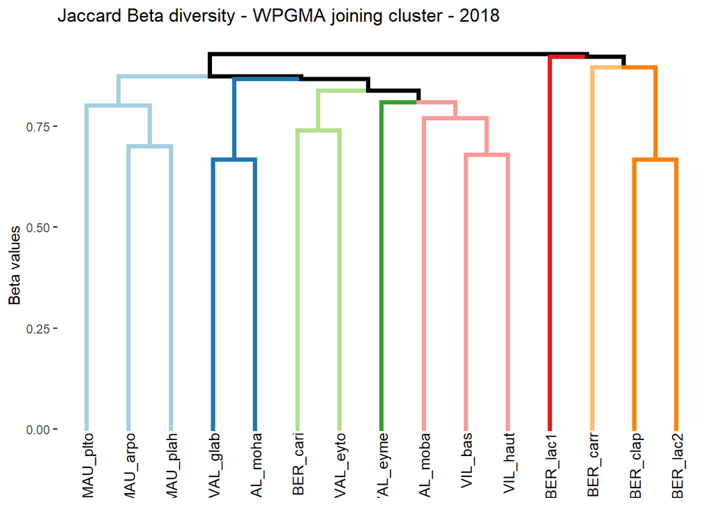

```r
fviz_dend(t_dat_prabs_clus_quit_18, k = 8, palette = "Paired", cex = 0.75, lwd = 1.5,
          color_labels_by_k = FALSE, ylab = "Beta values",
          main = "Jaccard Beta diversity - WPGMA joining cluster - 2018")
```

D’après les relevés de 2018, les placettes de la Bérarde (sauf Carrelet ripisylve) se distinguent des autres. Cette dernière est un peu différente car elle est située sur une terrasse alluviale très ancienne, largement végétalisée et se rapprochant d’une pelouse. Les placettes de Maurienne sont bien individualisées. Les placettes de Vallouise moraine haut et glacier sont proches. Surprenamment, celles de Villaroger se rapprochent de la placette moraine bas.  
**Attention :** il faut rappeler que seules les espèces sont prises en compte dans la comparaison, les recouvrements végétaux n’interviennent pas.

### 2.1.3 Représentation de la proximité floristique (présence/absence) 2D : NMDS

```r
# https://rdrr.io/cran/goeveg/man/dimcheckMDS.html
# avec deux dimensions on n'est pas trop mal meme si 3 seraient bien
# https://jonlefcheck.net/2012/10/24/nmds-tutorial-in-r/

dimcheckMDS(t_dat_prabs_18, distance = "jaccard", k = 6, trymax = 100, autotransform = FALSE)
```

```r
NMDS_18 <- metaMDS(t_dat_prabs_18, distance = "jaccard", binary = TRUE, trymax = 100, k = 2)
NMDS_18 # on passe d'un stress de 0.11 avec 3 dimensions, a un stress de 0.18 avec deux dimensions

stressplot(NMDS_18)
```

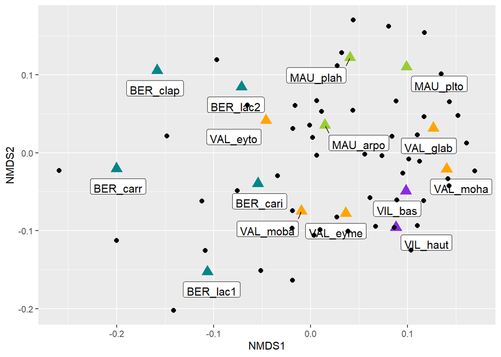

```r
# Extraction des données pour pouvoir utiliser ggplot

data.scores_18 <- as.data.frame(scores(NMDS_18))  # Using the scores function from vegan to extract the site scores and convert to a data.frame
data.scores_18$site <- rownames(data.scores_18)  # create a column of site names, from the rownames of data.scores
head(data.scores_18)  # look at the data

species.scores_18 <- as.data.frame(scores(NMDS_18, "species"))  # Using the scores function from vegan to extract the species scores and convert to a data.frame
species.scores_18$species <- rownames(species.scores_18)  # create a column of species, from the rownames of species.scores
head(species.scores_18)  # look at the data


# display.brewer.pal(n = 9, "Paired")
# brewer.pal(n = 9, "Paired")
col_paired <- c(rep("turquoise4",5), "orange", rep("olivedrab3",2), rep("orange",2), rep("blueviolet",2), "orange", "olivedrab3", "orange")

ggplot() +
    geom_point(data = data.scores_18, aes(x=NMDS1, y=NMDS2), size = 4, shape = 17, col = col_paired) +
    geom_label_repel(data = data.scores_18, aes(x=NMDS1, y=NMDS2,label=site), size= 4, vjust=0) +
    geom_point(data = species.scores_18, aes(x=NMDS1, y=NMDS2), color = "black", size = 2)
```

## 2.2 Indice de Sorensen

```r
d_18 <- betadiver(t_dat_prabs_18, "w") ## This should be equal to Sorensen index (binary Bray-Curtis in vegan)
d_21 <- betadiver(t_dat_prabs_21, "w") ## This should be equal to Sorensen index (binary Bray-Curtis in vegan)
d_18
```

```
##           BER_carr  BER_cari  BER_clap  BER_lac1  BER_lac2  VAL_eyme  MAU_arpo
## BER_cari 0.8400000
## BER_clap 0.7777778 0.9000000
## BER_lac1 0.8181818 0.6969697 0.8823529
## BER_lac2 0.8461538 0.6666667 0.5000000 0.9047619
## VAL_eyme 0.9333333 0.6097561 0.9200000 0.8421053 0.7931034
## MAU_arpo 0.8888889 0.7241379 0.8461538 0.8461538 0.6470588 0.6470588
## MAU_plah 0.9090909 0.7575758 0.8823529 0.8666667 0.8095238 0.8947368 0.5384615
## VAL_glab 0.9047619 0.8125000 0.8750000 0.9310345 0.8000000 0.6756757 0.8400000
## VAL_moba 0.7777778 0.6551724 0.8461538 0.7692308 0.7647059 0.6470588 0.7272727
## VIL_bas  0.9090909 0.8181818 0.8823529 0.9333333 0.8095238 0.7368421 0.7692308
## VIL_haut 0.9310345 0.8000000 0.9166667 0.8378378 0.8571429 0.6888889 0.7575758
## VAL_eyto 0.7777778 0.5862069 0.8461538 0.8461538 0.6470588 0.7647059 0.7272727
## MAU_plto 0.9259259 0.7894737 0.9090909 0.9428571 0.7692308 0.8139535 0.6774194
## VAL_moha 0.9200000 0.8888889 0.9000000 0.8787879 0.9166667 0.7073171 0.7241379
##           MAU_plah  VAL_glab  VAL_moba   VIL_bas  VIL_haut  VAL_eyto  MAU_plto
## BER_cari
## BER_clap
## BER_lac1
## BER_lac2
## VAL_eyme
## MAU_arpo
## MAU_plah
## VAL_glab 0.8620690
## VAL_moba 0.8461538 0.8400000
## VIL_bas  0.8000000 0.8620690 0.6153846
## VIL_haut 0.7837838 0.7777778 0.6363636 0.5135135
## VAL_eyto 0.6923077 0.6800000 0.7272727 0.8461538 0.8787879
## MAU_plto 0.6571429 0.7647059 0.9354839 0.7142857 0.7619048 0.7419355
## VAL_moha 0.8181818 0.5000000 0.7241379 0.6363636 0.7000000 0.8620690 0.7368421
```

```r
d_21
```

```
##           BER_carr  BER_cari  BER_clap  BER_lac1  BER_lac2  VAL_eyme  MAU_arpo
## BER_cari 0.8666667
## BER_clap 0.7500000 1.0000000
## BER_lac1 0.6000000 0.7222222 0.7272727
## BER_lac2        NA        NA        NA        NA
## VAL_eyme 0.9069767 0.7142857 0.9428571 0.8775510        NA
## MAU_arpo 0.9310345 0.7142857 0.9047619 0.8285714        NA 0.6250000
## MAU_plah 0.8709677 0.7297297 0.8260870 0.8918919        NA 0.7600000 0.6666667
## VAL_glab 0.9285714 0.8235294 0.9000000 0.9411765        NA 0.7446809 0.7575758
## VAL_moba 0.8181818 0.7857143 1.0000000 0.7857143        NA 0.7073171 0.7777778
## VIL_bas  0.7857143 0.6470588 0.9000000 0.8823529        NA 0.7872340 0.8181818
## VIL_haut 0.9411765 0.8000000 0.9230769 0.9000000        NA 0.7358491 0.7435897
## VAL_eyto 0.5862069 0.6000000 0.8095238 0.5428571        NA 0.7500000 0.8235294
## MAU_plto 0.8974359 0.7777778 0.9354839 0.9111111        NA 0.8275862 0.5909091
## VAL_moha 0.8750000 0.7894737 0.9166667 0.8421053        NA 0.7254902 0.7837838
##           MAU_plah  VAL_glab  VAL_moba   VIL_bas  VIL_haut  VAL_eyto  MAU_plto
## BER_cari
## BER_clap
## BER_lac1
## BER_lac2
## VAL_eyme
## MAU_arpo
## MAU_plah
## VAL_glab 0.6571429
## VAL_moba 1.0000000 0.8461538
## VIL_bas  0.6000000 0.7500000 0.8461538
## VIL_haut 0.7560976 0.7894737 0.7500000 0.6315789
## VAL_eyto 0.8333333 0.8787879 0.8518519 0.8181818 0.8974359
## MAU_plto 0.4347826 0.7209302 1.0000000 0.7209302 0.7959184 0.8636364
## VAL_moha 0.7435897 0.5555556 0.8000000 0.5555556 0.5714286 0.8918919 0.7872340
```

```r
ms18 <- mean(d_18)
ms21 <- mean(d_21)

# voir :
## https://sites.google.com/site/mb3gustame/hypothesis-tests/the-mantel-test
## https://mb3is.megx.net/gustame/dissimilarity-based-methods/nmds
```

# 3. Comparaison inter-années

## 3.1 Diversité spécifique

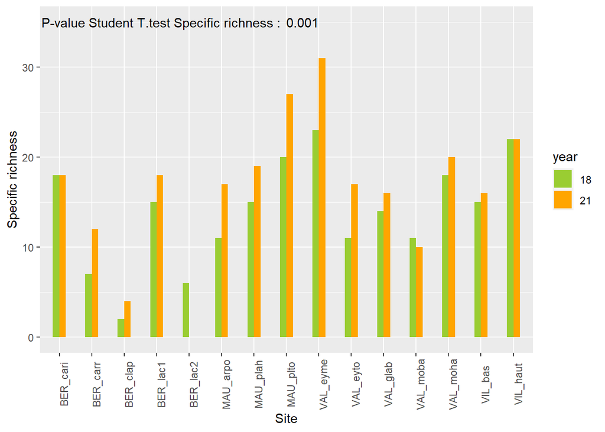

```r
ggplot(richness_long, aes(x = site_18, y = rich, fill = year)) +
  geom_bar(stat = "identity", width =.4, position=position_dodge(), size = 1) +
  scale_fill_manual(values = c("olivedrab3","orange","turquoise4","blueviolet")) +
  theme(legend.position = "right", axis.text.x = element_text(angle = 90)) +
  xlab("Site") +
  ylab("Specific richness") +
  annotate("text", x = 4.2, y = 35, label = "P-value Student T.test Specific richness : ") +
  annotate("text", x = 8.5, y = 35, label = round(student_rich$p.value, 4))
```

Sur 11 des 14 sites on a en 2021 plus de taxons observés qu’en 2018. Plusieurs hypothèses :  
+ + + c’est un biais observateur, plus forte détection en 2021 pour différentes raisons (date et avancement de la végétation, temps passé sur la placette…) mais paraît peu probable d’une part car cette tendance est la même sur l’ensemble des sites et d’autre part car à priori ce biais s’exprimerait plus sur les abondances que sur la présence/absence ;  
+ + + il y a réellement une augmentaton de la diversité spécifique sur les plots en lien avec la végétalisation des dépôts alluviaux et des moraines ;  
+ + + mélange des deux.

**A noter :** la placette “plan du lac torrent” a été détruite en 2021 et les traits, comptages et relevés n’ont donc pas été réalisés.

## 3.2 Indice de Jaccard

On calcule maintenant l’indice de Jaccard pour chaque placette entre 2018 et 2021.

```r
# On ne peut mettre qu'un seul tableau en entrée de vegdist, il faut donc ruser pour calculer les distances de Jaccard entre chaque site (année 1 vs année 2)

taxons <- rownames(dat_prabs_21)

colnames(dat_prabs_18) <- paste0(colnames(dat_prabs_18),"18")
colnames(dat_prabs_21) <- paste0(colnames(dat_prabs_21),"21")

dat <- vector("list", 14) # on ne prend pas en compte "lac torrent" détruite en 2021

for (i in 1:14) {
  dat[[i]] <- cbind(dat_prabs_18[,-5][i],dat_prabs_21[,-5][i])
}

names(dat) <- y

# On a un data frame par site pour les deux années.

t_dat <- vector ("list", length(dat))

for (i in 1:14) {
  t_dat[[i]] <- (t(as.data.frame(dat[i])))
  t_dat[[i]] <- as.data.frame(as.matrix(t_dat[[i]]))
}

names(t_dat) <- paste0(y,"_t")

# Et la meme chose transposee

# Maintenant on fait la boucle pour calculer les distances sur chaque tableau

v_dist <- vector("numeric", length(t_dat))

for (i in 1:14) {
 v_dist[[i]] <- vegdist(t_dat[[i]], binary = TRUE, method = "jaccard")

}

names(v_dist) <- y

df_v_dist <- as.data.frame(v_dist)
colnames(df_v_dist) <- "Dist_Jaccard"

df_v_dist <- df_v_dist[order(rownames(df_v_dist)), , drop = F]

df_v_dist %>%
  kbl() %>%
  kable_paper(full_width = F) %>%
  column_spec(2, color =  spec_color(df_v_dist$Dist_Jaccard, begin = 0, end = 1)) %>%
  pack_rows("VENEON", 1,4) %>%
  pack_rows("MAURIENNE", 5,7) %>%
  pack_rows("VALLOUISE", 8,12) %>%
  pack_rows("VILLAROGER", 13,14)
```

|  | Dist_Jaccard |
| --- | --- |
| **VENEON** |  |
| BER_cari | 0.5000000 |
| BER_carr | 0.6428571 |
| BER_clap | 0.5000000 |
| BER_lacrip | 0.3500000 |
| **MAURIENNE** |  |
| MAU_arpo | 0.4444444 |
| MAU_plah | 0.5833333 |
| MAU_plto | 0.5757576 |
| **VALLOUISE** |  |
| VAL_eyme | 0.3636364 |
| VAL_eyto | 0.4444444 |
| VAL_glab | 0.3333333 |
| VAL_moba | 0.6875000 |
| VAL_moha | 0.4800000 |
| **VILLAROGER** |  |
| VIL_bas | 0.5238095 |
| VIL_haut | 0.1666667 |

Certaines placettes ont une forte similarité (Villaroger haut, Vallouise Glacier blanc, Bérarde Plan du Lac ripisylve) indiquant peu de changement de la composition entre 2018 et 2021. La majorité des indices tourne entre 0.4 et 0.6. C’est sur Vallouise moraine bas que la dissimilarité 2018/2021 est la plus importante.

```r
## POUR 2018

# barplot(specnumber(t_dat_prabs_18), las = 2) # species richness

specpool(t_dat_prabs_18, smallsample = TRUE) # c'est pareil avec ou sans le small sample
```

|  | Species | chao | chao.se | jack1 | jack1.se | jack2 | boot | boot.se | n |
| --- | --- | --- | --- | --- | --- | --- | --- | --- | --- |
| All | 94 | 136.9528 | 16.63856 | 137.8667 | 14.1283 | 159.2857 | 113.8592 | 7.446124 | 15 |

```r
#estimateR(t_dat_prabs_18)
#accum18 <- specaccum(t_dat_prabs_18, method = "random")
#plot(accum18, random = FALSE, ci.type = "polygon", ci.col = "grey", col = "red")
#preston18 <- prestonfit(colSums(t_dat_prabs_18))
#plot(preston18)
#veiledspec(preston18)
```

```r
## POUR 2021
specpool(na.omit(t_dat_prabs_21), smallsample = TRUE)
```

|  | Species | chao | chao.se | jack1 | jack1.se | jack2 | boot | boot.se | n |
| --- | --- | --- | --- | --- | --- | --- | --- | --- | --- |
| All | 109 | 161.1671 | 19.14192 | 158.2143 | 17.32419 | 183.8626 | 131.2005 | 8.958307 | 14 |

## 3.3 Exemple de comparaison de données (Eychauda mélézin)

```r
# Elements communs
intersect(chr_list_21$EYCH_meleze21, chr_list_18$EYCH_meleze18)
```

```
##  [1] "Alc_alp/trans" "Ant_vul"       "Asp_cyn"       "Bis_lae"
##  [5] "Cam_sch"       "Dia_sax"       "Glo_cor"       "Lot_alp"
##  [9] "Min_lar"       "Pil_off/pel"   "Pla_ser"       "Pot_ver"
## [13] "Sax_pan"       "Sed_alb"       "Sed_mon"       "Sem_ara"
## [17] "Thy_pul"       "Tri_pal"       "Tri_sax"       "Ver_fru"
## [21] "Vin_hir"
```

```r
# Elements dans 21 mais pas dans 18
setdiff(chr_list_21$EYCH_meleze21, chr_list_18$EYCH_meleze18)
```

```
##  [1] "Des_fle"  "Eup_sal"  "Fes_rub." "Gal_obl"  "Hel_num"  "Lar_dec"
##  [7] "Poa_alp"  "Sax_mos"  "Sed_das"  "Sor_ari"
```

```r
# Elements dans 18 mais pas dans 21
setdiff(chr_list_18$EYCH_meleze18, chr_list_21$EYCH_meleze21)
```

```
## [1] "Agr_rup" "Ros_sp."
```

De nombreuses espèces suplémentaires en 21 mais on est sur une placette très grande donc il y a probablement de la sous-observation en 18. Et peut-être des erreurs de détermination.

## 3.4 Représentation de la proximité floristique (abondance) et des trajectoires inter-années 2D : NMDS

Certaines placettes sont scindées en plusieurs morceaux et les relevés bota ont été réalisés séparément. Il faudrait merger les abondances pour renseigner la liste de taxons pour un site sur une seule colonne.

De plus, on a certains taxons dont on ne connaît pas l’abondance et les NA ne sont pas acceptés pour calculer les NMDS. On les remplace mannuellement par la valeur de 2021.

La NMDS est une méthode de représentation permettant de traduire les relations de X relevés en X dimensions en une représentation 2 (ou plus) D en se basant sur les distances de Bray-Curtis. On peut la faire en présence/absence (voir plus haut), ou en abondance (comme ici). Pour ça, il suffit de changer l’argument `binary = TRUE` en `binary = FALSE`.

```r
## 2018
nmds_2018_pour <- as.data.frame(dat_pourc_18)

nmds_2018_pour <- nmds_2018_pour[,c(1:142)] %>%
map_dfr(as.numeric)

nmds_2018_pour <- as.matrix(nmds_2018_pour)


set.seed(123)
nmds_tot_2018_pour <- metaMDS(nmds_2018_pour, trymax = 100, distance = "bray",
                              binary = FALSE, na.rm = TRUE)

nmds_tot_2018_pour
stressplot(nmds_tot_2018_pour) # vérification
```

```r
plot(nmds_tot_2018_pour)
```

```r
data.scores_2018_pour <- as.data.frame(scores(nmds_tot_2018_pour)) # Sites
data.scores_2018_pour$site <- rownames(dat_pourc_18)
data.scores_2018_pour$secteur <- c(rep("VENEON",5), rep("VALLOUISE",3), rep("MAURIENNE",4), rep("VALLOUISE",4), rep("VILLAROGER",2))

species.scores_2018_pour <- as.data.frame(scores(nmds_tot_2018_pour, "species")) # Taxons
species.scores_2018_pour$species <- rownames(species.scores_2018_pour)


veneon_pour <- data.scores_2018_pour[data.scores_2018_pour$secteur == "VENEON", ][chull(data.scores_2018_pour[data.scores_2018_pour$secteur == "VENEON", c("NMDS1", "NMDS2")]), ]

vallouise_pour <- data.scores_2018_pour[data.scores_2018_pour$secteur == "VALLOUISE", ][chull(data.scores_2018_pour[data.scores_2018_pour$secteur == "VALLOUISE", c("NMDS1", "NMDS2")]), ]

maurienne_pour <- data.scores_2018_pour[data.scores_2018_pour$secteur == "MAURIENNE", ][chull(data.scores_2018_pour[data.scores_2018_pour$secteur == "MAURIENNE", c("NMDS1", "NMDS2")]), ]

villaroger_pour <- data.scores_2018_pour[data.scores_2018_pour$secteur == "VILLAROGER", ][chull(data.scores_2018_pour[data.scores_2018_pour$secteur == "VILLAROGER", c("NMDS1", "NMDS2")]), ]


hull.data_2018_pour <- rbind(veneon_pour, vallouise_pour, maurienne_pour, villaroger_pour)

hull.data_2018_pour
```

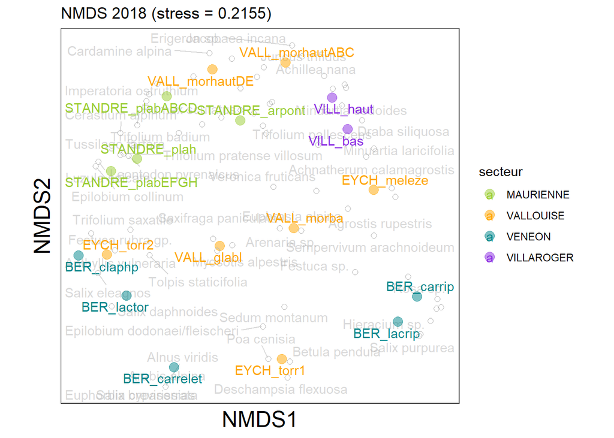

```r
ggplot() +
  geom_text_repel(data = species.scores_2018_pour, aes(x = NMDS1, y = NMDS2,
                 label = species), alpha = 0.5,  color = "grey70") +
  geom_point(data = data.scores_2018_pour, aes(x = NMDS1, y = NMDS2, color = secteur),
             size = 3.5, alpha = 0.5) +
  geom_text_repel(data = data.scores_2018_pour, aes(x = NMDS1, y = NMDS2,
            color =  secteur, label = site)) +
  geom_point(data = species.scores_2018_pour, aes(x = NMDS1, y = NMDS2), size = 2,
             pch = 1, color = "grey70") +
  coord_equal() +
  theme_bw() +
  scale_color_manual(values = c("olivedrab3","orange","turquoise4","blueviolet")) +
  theme(axis.text.x = element_blank(),
        axis.text.y = element_blank(),
        axis.ticks = element_blank(),
        axis.title.x = element_text(size = 18),
        axis.title.y = element_text(size = 18),
        panel.background = element_blank(),
        panel.grid.major = element_blank(),
        panel.grid.minor = element_blank(),
        plot.background = element_blank()) +
  ggtitle(label = "NMDS 2018 (stress = 0.2155)")
```

Sans surprise on retrouve deux pools constitués respectivement des placettes de Maurienne et de Villaroger qui se rapprochent floristiquement. Ces deux pools sont relativement proches entre eux, et se rapprochent également des placettes du haut de la moraine de Vallouise. On a un gradient altitudinal du bas vers le haut de la figure. **A noter les sous-placettes qu’il faudrait regrouper, celles de la placette Vallouise_moraine_haut se retrouvent proches mais celles d’Eychauda torrent sont assez éloignées.**

Les placettes de La Bérarde sont bien distinctes de toutes les placettes de Maurienne, Vallouise et Villaroger ; elles se rapprochent des placettes de l’Eychauda torrent. On a une ségrégation horizontale entre les domaines versant/moraine et fluvio-glaciaire.

```r
## 2021
nmds_2021_pour <- as.data.frame(dat_pourc_21[-5,])

nmds_2021_pour <- nmds_2021_pour[,c(1:142)] %>%
map_dfr(as.numeric)

nmds_2021_pour <- as.matrix(nmds_2021_pour)

set.seed(123)
nmds_tot_2021_pour <- metaMDS(nmds_2021_pour, trymax = 100, distance = "bray",
                              binary = FALSE, na.rm = TRUE)

nmds_tot_2021_pour
stressplot(nmds_tot_2021_pour) # vérification
```

```r
plot(nmds_tot_2021_pour)
```

```r
data.scores_2021_pour <- as.data.frame(scores(nmds_tot_2021_pour)) # Sites
data.scores_2021_pour$site <- rownames(dat_pourc_21[-5,])
data.scores_2021_pour$secteur <- c(rep("VENEON",4), rep("VALLOUISE",3), rep("MAURIENNE",4), rep("VALLOUISE",4), rep("VILLAROGER",2))



species.scores_2021_pour <- as.data.frame(scores(nmds_tot_2021_pour, "species")) # Taxons
species.scores_2021_pour$species <- rownames(species.scores_2021_pour)


veneon_pour_21 <- data.scores_2021_pour[data.scores_2021_pour$secteur == "VENEON", ][chull(data.scores_2021_pour[data.scores_2021_pour$secteur == "VENEON", c("NMDS1", "NMDS2")]), ]

vallouise_pour_21 <- data.scores_2021_pour[data.scores_2021_pour$secteur == "VALLOUISE", ][chull(data.scores_2021_pour[data.scores_2021_pour$secteur == "VALLOUISE", c("NMDS1", "NMDS2")]), ]

maurienne_pour_21 <- data.scores_2021_pour[data.scores_2021_pour$secteur == "MAURIENNE", ][chull(data.scores_2021_pour[data.scores_2021_pour$secteur == "MAURIENNE", c("NMDS1", "NMDS2")]), ]

villaroger_pour_21 <- data.scores_2021_pour[data.scores_2021_pour$secteur == "VILLAROGER", ][chull(data.scores_2021_pour[data.scores_2021_pour$secteur == "VILLAROGER", c("NMDS1", "NMDS2")]), ]


hull.data_2021_pour <- rbind(veneon_pour_21, vallouise_pour_21, maurienne_pour_21, villaroger_pour_21)

hull.data_2021_pour
```

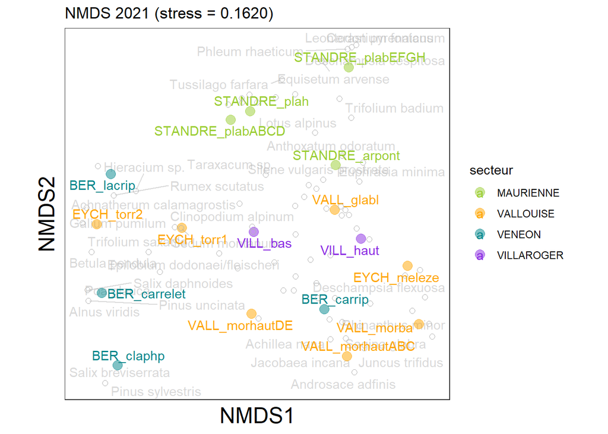

```r
ggplot() +
  geom_text_repel(data = species.scores_2021_pour, aes(x = NMDS1, y = NMDS2,
                 label = species), alpha = 0.5,  color = "grey70") +
  geom_point(data = data.scores_2021_pour, aes(x = NMDS1, y = NMDS2, color = secteur),
             size = 3.5, alpha = 0.5) +
  geom_text_repel(data = data.scores_2021_pour, aes(x = NMDS1, y = NMDS2,
            color =  secteur, label = site)) +
  geom_point(data = species.scores_2021_pour, aes(x = NMDS1, y = NMDS2), size = 2,
             pch = 1, color = "grey70") +
  coord_equal() +
  theme_bw() +
  scale_color_manual(values = c("olivedrab3","orange","turquoise4","blueviolet")) +
  theme(axis.text.x = element_blank(),
        axis.text.y = element_blank(),
        axis.ticks = element_blank(),
        axis.title.x = element_text(size = 18),
        axis.title.y = element_text(size = 18),
        panel.background = element_blank(),
        panel.grid.major = element_blank(),
        panel.grid.minor = element_blank(),
        plot.background = element_blank()) +
  ggtitle(label = "NMDS 2021 (stress = 0.1620)")
```

En 2021 on a un pattern un peu différent, avec cette fois la “fausse” placette du carrelet (rip) qui se rapproche plus de celles de Vallouise, ce qui est logique puisque elle ressemble à une pelouse (terrasse alluviale très ancienne et très végétalisée).

On peut ensuite étudier la trajectoire de chaque relevé. Pour cela, on réalise une NMDS générale.

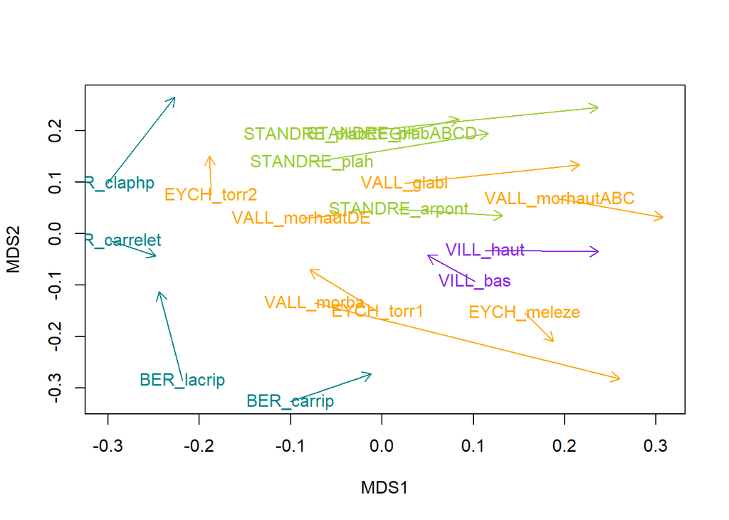

```r
nmds_1_big <- as.data.frame(dat_pourc[c(-5,-23),]) # On enleve lac torrent

nmds_big <- nmds_1_big[,c(-1)]
str(nmds_big)

nmds_big <- nmds_big %>%
map_dfr(as.numeric)

nmds_big <- as.matrix(nmds_big)

set.seed(123)
nmds_tot <- metaMDS(nmds_big, trymax = 100, distance = "bray",
                    binary = FALSE)
nmds_tot

year <- c(rep("2018",17), rep("2021",17))

site_tot <- c(rownames(dat_pourc_18[-5,]), rownames(dat_pourc_21[-5,]))

couleurs <- c(rep("turquoise4",4), rep("orange",3), rep("olivedrab3",4), rep("orange",4), rep("blueviolet",2), rep("turquoise4",4), rep("orange",3), rep("olivedrab3",4), rep("orange",4), rep("blueviolet",2))

MultiDyn(MultCOO = nmds_tot$points,
         FACTime = factor(year),
         FACT2 = factor(site_tot),
         COL = couleurs,
         ARR = TRUE) # Merci Renaud !
```

Il semble y avoir un déplacement partagé vers la droite, bien marqué pour les placettes de St André, certaines de Vallouise et une de Villaroger. Il semble y avoir un lien avec la formation puisque ce sont des placettes clairement identifiées en moraine ou versant qui adoptent cette dynamique (y compris la placette de Carrelet non délimitée = carrip, disposée sur une pelouse se rapprochant d’une communauté de versant). Les placettes situées sur les alluvions se déplacent moins dans le plan de la NMDS et de façon moins uni-directionnelle.  
Globalement, on pourrait dire que les placettes dont la richesse spécifique est la plus importante (donc les placettes situées sur les moraines et les versants) sont celles qui évoluent de plus.

**Il faudrait regarder avec un modèle quel facteur environnemental (altitude, perturbations, géomorpho…) joue le plus sur l’indice de Jaccard.**

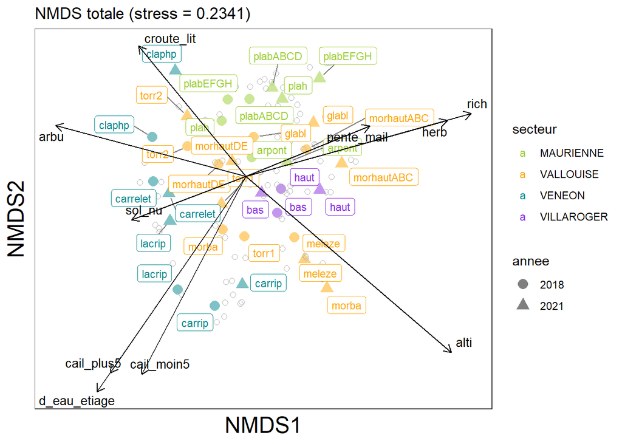

De la même façon qu’une comparaison de moyennes avec `anova`, on compare ici les compositions des commuanutés de chaque placette avec le test `anosim`. La placette Plan du Lac - torrent (Bérarde) est supprimée.

“The ANOSIM statistic compares the mean of ranked dissimilarities between groups to the mean of ranked dissimilarities within groups. An R value close to”1.0" suggests dissimilarity between groups while an R value close to “0” suggests an even distribution of high and low ranks within and between groups. R values below “0” suggest that dissimilarities are greater within groups than between groups. See Clarke and Gorley (2001) for a guide to interpreting ANOSIM R values." https://sites.google.com/site/mb3gustame/hypothesis-tests/anosim

```r
anosim(dat_pourc[c(-5,-23),-1], grouping = dat_pourc[c(-5,-23),]$year, permutations = 999, distance = "bray", strata = NULL, parallel = getOption("mc.cores")) # total
```

```
##
## Call:
## anosim(x = dat_pourc[c(-5, -23), -1], grouping = dat_pourc[c(-5,      -23), ]$year, permutations = 999, distance = "bray", strata = NULL,      parallel = getOption("mc.cores"))
## Dissimilarity: bray
##
## ANOSIM statistic R: 0.0375
##       Significance: 0.174
##
## Permutation: free
## Number of permutations: 999
```

# 4. variables environnementales

Les recouvrements de sol nu ne sont pas fiables car la prise de données a été différente en 2018 et 2021 (prise en compte de la litière dans un cas). On se concentre sur le recouvrement herbacé, qui est à la fois le plus fiable et celui qui concerne toutes les placettes (contrairement au recouvrement arbustif qui est présent uniquement sur certaines).

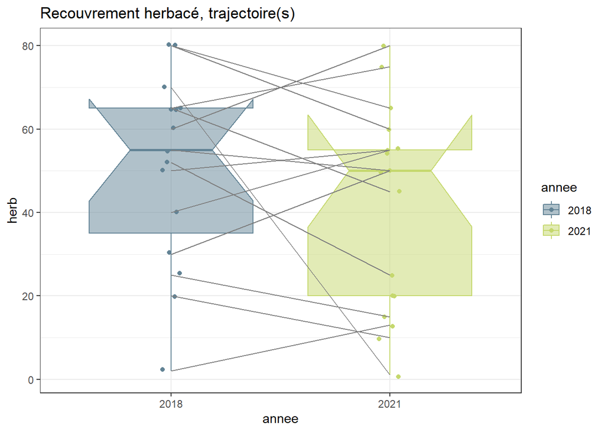

```r
res.kruskal_annee <- relev_var %>% kruskal.test(herb ~ annee, paired = TRUE)
res.kruskal_annee
```

```
##
##  Kruskal-Wallis rank sum test
##
## data:  .
## Kruskal-Wallis chi-squared = 354.97, df = 18, p-value < 2.2e-16
```